# Music Insights Part 2

Olivia Abbott

11/14/2019

We are first going to add a continuous variable to our person table. This variable is going to hold each person’s average rating on all of the songs that they rated. We use the aggregate function to collect the mean for each persons ratings. This information is stored in a table called df which we then join with our current person table.

```r
df <- aggregate(ratings$rating, list(pseudonym = ratings$pseudonym), FUN=function(x) mean(as.numeric(x)))
colnames(df)[colnames(df) == "x"] <- "average_rating"
person <- left_join(person, df, by = "pseudonym")
```

We are next going to create a model to predict each person’s average rating. We need to load the caret library in order to create our model.

The first step is that we need to remove any people from our person table that have a NA value for the average rating. I create the person_info table to hold the person data without any NA values for average rating. We then split the data into a train and test set. Then we creat the model using the train dataset. We are then able to create a prediction using our model and the test set.

```r
library(caret)
person$time_submitted <- as.POSIXct(person$time_submitted)
person_info <- as_tibble(person) %>% subset(!is.na(average_rating))
set.seed(125)
sample_selection <- createDataPartition(person_info$average_rating, p = 0.75, list = FALSE)
person_train <- person_info[sample_selection, ]
person_test <- person_info[-sample_selection, ]

person_train_model <- lm(person_train, formula = average_rating ~ sex + academic_major + academic_level + year_born)
summary(person_train_model)
```

```
##
## Call:
## lm(formula = average_rating ~ sex + academic_major + academic_level +
##     year_born, data = person_train)
##
## Residuals:
##      Min       1Q   Median       3Q      Max
## -1.60090 -0.65337 -0.08938  0.50399  2.16654
##
## Coefficients:
##                                 Estimate Std. Error t value Pr(>|t|)
## (Intercept)                    -23.15816   62.26125  -0.372    0.713
## sexMale                         -0.66215    0.49986  -1.325    0.196
## academic_majorComputer Science   0.81547    1.04527   0.780    0.442
## academic_majorMath               1.24154    1.29466   0.959    0.346
## academic_levelSenior            -0.34670    0.44736  -0.775    0.445
## academic_levelSophomore         -0.12250    1.11768  -0.110    0.914
## year_born                        0.01446    0.03126   0.463    0.647
##
## Residual standard error: 1.02 on 27 degrees of freedom
##   (1 observation deleted due to missingness)
## Multiple R-squared:  0.1129, Adjusted R-squared:  -0.08429
## F-statistic: 0.5724 on 6 and 27 DF,  p-value: 0.7487
```

```r
prediction <- person_train_model %>% predict(person_test)

R2(prediction, person_test$average_rating)
```

```
## [1] 0.3656873
```

```r
MAE(prediction, person_test$average_rating)
```

```
## [1] 1.400176
```

```r
RMSE(prediction, person_test$average_rating)
```

```
## [1] 1.787492
```

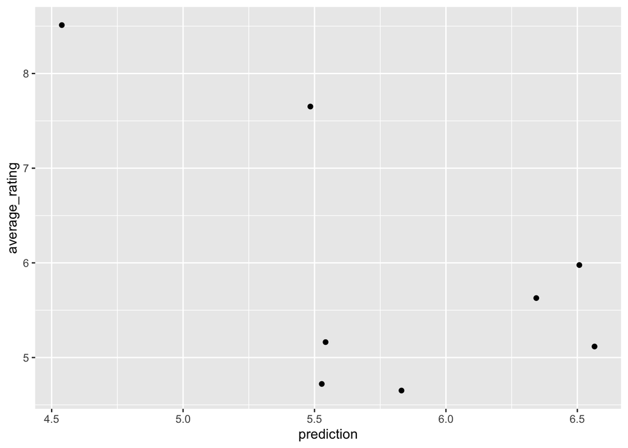

```r
ggplot(person_test, aes(x = prediction, y = average_rating)) + geom_point()
```

From the results of our training model you can see that the p value is very high (0.7487) which means that the variables we created our model with are not good variables to use to predict the person’s average rating.